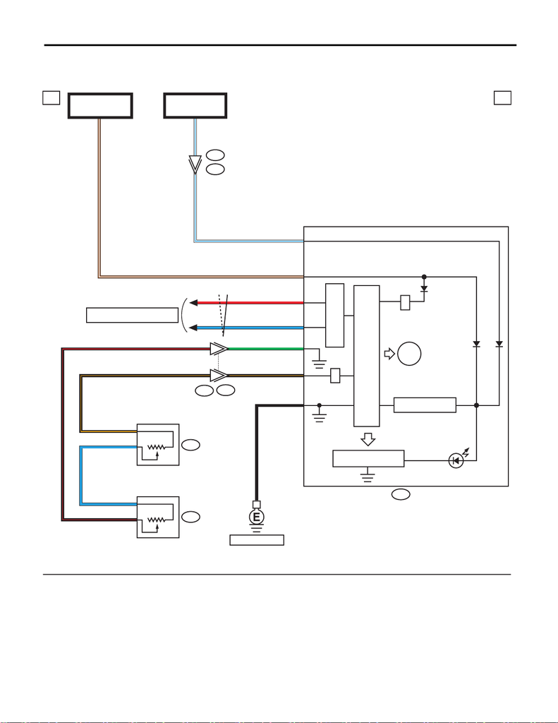

Fuel Gauge System

WIRING SYSTEM

23.Fuel Gauge System

A: WIRING DIAGRAM

WI-44447

a a

R59

R58

i53

R98

3

B551

i229

i10

I/F

I/F

4

20

38

33

32

BR/W 20

B

25

37G

L

R

B/O

1

2

L

L

1

B/R

B/O

B/R

40W/L

B/O

BR/W

W/LW/L

B

1

1

CAN TRANSCEIVER &

RECEIVER

MICRO COMPUTER

DRIVE CIRCUIT

POWER SUPPLY

CIRCUIT

FUEL LEVEL

FUEL PUMP ASSY

(FUEL LEVEL SENSOR)

FUEL SUB LEVEL

SENSOR

FB-12

F/B FUSE NO. 2

(IG)

FB-18

F/B FUSE NO. 7

(B)

COMBINATION METER

REF. TO GND [e]

REF. TO CAN COMMUNICATION

SYSTEM [b]

: ENGINE TYPE FA : 2

ENGINE TYPE EJ : 4

FUEL

GAUGE

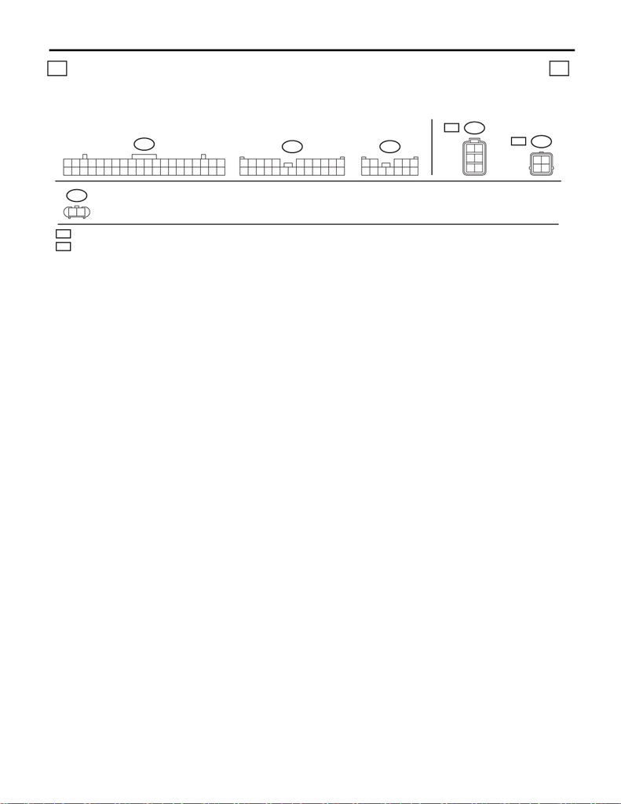

Fuel Gauge System

WIRING SYSTEM

WI-44448

b b

i10

11 12

9

10

2

18

20

21 22 23 24 26

25

27 28 29 30 31 32 33 34 35 36 37 38 39 40

17

i229

12 345

6789

10 11 12

(GR)

R58

12

34

56

EJ

:

R58

FA

:

43

1

2

10 11

12 13 14 15 16 17 18 19 20 21 22 23 24

567

i53

R59

2

1

EJ

FA

LIST OF CONNECTORS

: ENGINE TYPE EJ

: ENGINE TYPE FA